# Lab 10

December 11th 2017

## Simple linear regression

## Line of the best fit

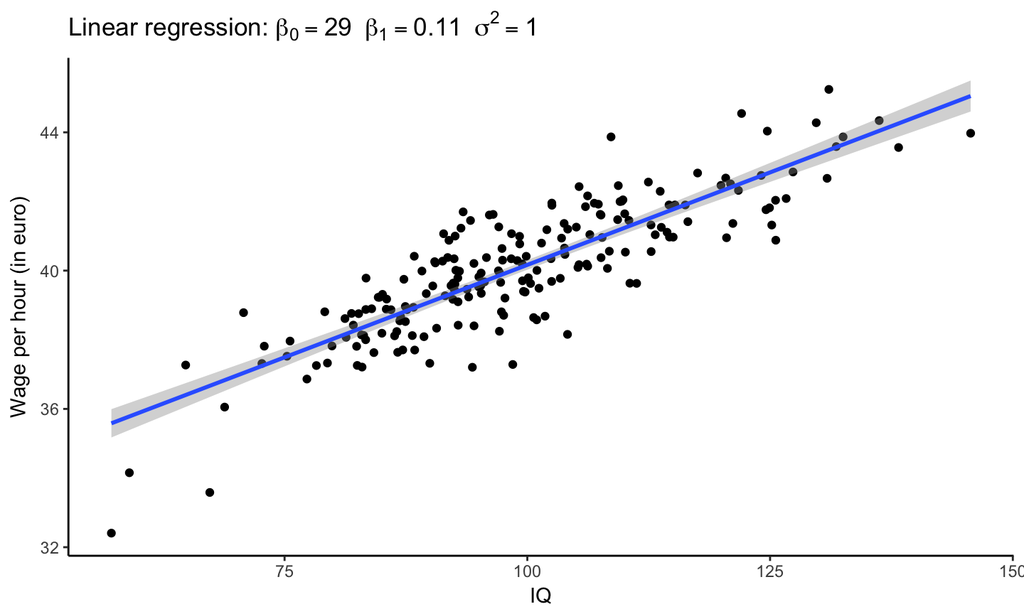

## Understanding parameters

- **intercept (\(\beta_0\))** - place of the crossing of regression line and y-axis, e.g. what would be average wage for a person with 0 IQ
- because such intercept cannot be interpretted in a substantive way (imagine a person with 0 IQ), a popular approach is to center predictors on mean value (i.e. take mean as 0); as a result intercept can be interpretted, e.g. what would be average wage of a person with average IQ

## Understanding parameters

- **slope (\(\beta_0\))** - how much outcome variable will increase if we change a predictor by 1 unit, e.g. what is the difference in wages between people with IQ of 100 and 101
- commonly in psychology predictors have scales which are difficult to interpret, e.g. we don't really now what it means that a person obtained 16 points on a test, and how it is different from a person who obtained 17 points
- to operate on a more interpretable scales, we often standardize both predictor and outcome variables (this is also handy in the case of models with more than 1 predictor) - 1 unit becomes a 1 standard deviation
- because standardizing is also centering, there is no loss of interpretability of the intercept

## Understanding parameters

- **variance of residuals (\(\sigma^2\))** - variance of the differences between observed and predicted values
- this value explains how much unexplained variance of the outcome variable is still left (after we fitted regression line)
- by looking at the standard deviation (\(\sigma\)), we can say what is the average error we make by accepting the regression line as our model

## Understanding parameters

- **grey area** - explains uncertainty associated with out parameters' estimates - in Bayesian approach this is 95% credible interval
- in other words in Bayesian approach, we do not claim that the regression line is strictly the blue one, but rather that it lays somewhere over the gray region

## Bayesian Linear Model

- \(y \sim \mathcal{N}(\mu, \sigma^2)\)
- \(\mu = \beta_0 + \beta_1 * x\)
- in other words \(y\) is distributed according to Normal distribution with mean \(\mu\) and variance \(\sigma^2\)
- note that \(\mu\) changes (is conditional) on the value of \(x\)

## Bayesian Linear Model

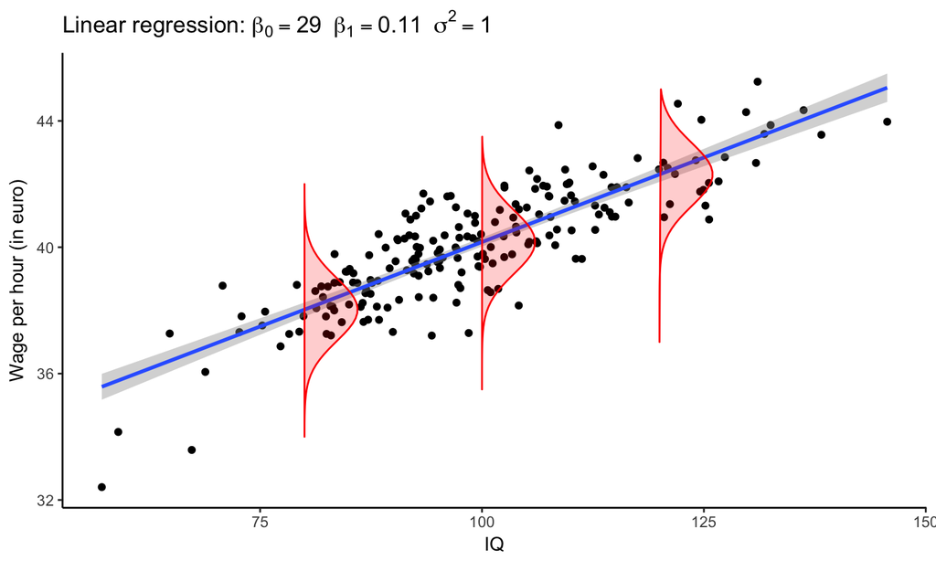

- notice that we assume that the variance of errors is the same for all values of IQ - this is so called homoscedasticity assumption

## Priors on the parameters

- \(\beta_0 \sim \mathcal{N}(m_0, s_0)\)
- \(\beta_0 \sim \mathcal{N}(m_1, s_1)\)
- \(\sigma \sim \mathcal{U}(lower, upper)\)
- values of the hyperparameters depend largely on the scale of x and y variables
- for weakly informative priors (standardized variables) it is common to set \(m_0\) and \(m_1\) to 0, \(s_0\) and \(s_1\) to 10, lower to \(1e-3\) and upper to \(1e+3\)

## Robust linear regression

- As with robust Bayesian t-test, we can use Student's t distribution, instead of Normal distribution to model our data, robustly against outliers
- \(y \sim \mathcal{T}(\mu, \sigma^2, \nu)\)
- \(\mu = \beta_0 + \beta_1 * x\)
- With prior on normality parameter \(\nu\), the same as previously:
- \((\nu - 1) \sim \mathcal{E}(1/29)\)